# Project #2 - Personal Loan Campaign Purchase Prediction

## Problem Statement

### Context

AllLife Bank is a US bank that has a growing customer base. The majority of its customers are liability customers (depositors) with varying sizes of deposits. The number of customers who are also borrowers (asset customers) is quite small, and the bank is interested in expanding this base rapidly to bring in more loan business and in the process, earn more through the interest on loans. In particular, the management wants to explore ways of converting its liability customers to personal loan customers (while retaining them as depositors).

A campaign that the bank ran last year for liability customers showed a healthy conversion rate of over 9% success. This has encouraged the retail marketing department to devise campaigns with better target marketing to increase the success ratio.

You as a Data scientist at AllLife bank have to build a model that will help the marketing department to identify the potential customers who have a higher probability of purchasing the loan.

### Objective

To predict whether a liability customer will buy personal loans, to understand which customer attributes are most significant in driving purchases, and identify which segment of customers to target more.

### Data Dictionary

- `ID`: Customer ID
- `Age`: Customer’s age in completed years
- `Experience`: #years of professional experience
- `Income`: Annual income of the customer (in thousand dollars)
- `ZIP Code`: Home Address ZIP code.
- `Family`: the Family size of the customer
- `CCAvg`: Average spending on credit cards per month (in thousand dollars)
- `Education`: Education Level. 1: Undergrad; 2: Graduate;3: Advanced/Professional
- `Mortgage`: Value of house mortgage if any. (in thousand dollars)
- `Personal_Loan`: Did this customer accept the personal loan offered in the last campaign? (0: No, 1: Yes)
- `Securities_Account`: Does the customer have securities account with the bank? (0: No, 1: Yes)
- `CD_Account`: Does the customer have a certificate of deposit (CD) account with the bank? (0: No, 1: Yes)
- `Online`: Do customers use internet banking facilities? (0: No, 1: Yes)
- `CreditCard`: Does the customer use a credit card issued by any other bank (excluding All life Bank)? (0: No, 1: Yes)

## Importing the necessary libraries

```python
# Installing the libraries with the specified version.
!pip install numpy==1.25.2 pandas==1.5.3 matplotlib==3.7.1 seaborn==0.13.1 scikit-learn==1.2.2 sklearn-pandas==2.2.0 -q --user
```

**Note**:

1. After running the above cell, kindly restart the notebook kernel (for Jupyter Notebook) or runtime (for Google Colab), write the relevant code for the project from the next cell, and run all cells sequentially from the next cell.
2. On executing the above line of code, you might see a warning regarding package dependencies. This error message can be ignored as the above code ensures that all necessary libraries and their dependencies are maintained to successfully execute the code in this notebook.

```python
# we import pandas and numpy for loading and manipulating data
import pandas as pd
import numpy as np

# we import matplotlib and seaborn for data visualization
import matplotlib.pyplot as plt
import seaborn as sns

# we use scikit-learn to split data into training and test sets
from sklearn.model_selection import train_test_split

# to build decision tree model for prediction
from sklearn.tree import DecisionTreeClassifier
from sklearn import tree

# to tune different models
from sklearn.model_selection import GridSearchCV

# to compute classification metrics
from sklearn.metrics import (
    confusion_matrix,
    accuracy_score,
    precision_score,
    recall_score,
    f1_score,
)

# to suppress unnecessary warnings
import warnings
warnings.filterwarnings("ignore")
```

## Loading the data from the dataset

```python
# mount google drive to current colab notebook
from google.colab import drive
drive.mount('/content/drive')
```

```python
# read the data from the dataset and load it into a pandas dataframe
original_data = pd.read_csv("/content/drive/My Drive/Texas McCombs/Machine Learning/Project #2/loan-modelling-data.csv")
```

```python
# create a new copy of the data
data = original_data.copy()
```

## Data Overview

- Observations
- Sanity checks
- Data type review
- Summary statistics

```python
# view the first 5 rows of the data
data.head()
```

|  | ID | Age | Experience | Income | ZIPCode | Family | CCAvg | Education | Mortgage | Personal_Loan | Securities_Account | CD_Account | Online | CreditCard |
| --- | --- | --- | --- | --- | --- | --- | --- | --- | --- | --- | --- | --- | --- | --- |
| 0 | 1 | 25 | 1 | 49 | 91107 | 4 | 1.6 | 1 | 0 | 0 | 1 | 0 | 0 | 0 |
| 1 | 2 | 45 | 19 | 34 | 90089 | 3 | 1.5 | 1 | 0 | 0 | 1 | 0 | 0 | 0 |
| 2 | 3 | 39 | 15 | 11 | 94720 | 1 | 1.0 | 1 | 0 | 0 | 0 | 0 | 0 | 0 |
| 3 | 4 | 35 | 9 | 100 | 94112 | 1 | 2.7 | 2 | 0 | 0 | 0 | 0 | 0 | 0 |
| 4 | 5 | 35 | 8 | 45 | 91330 | 4 | 1.0 | 2 | 0 | 0 | 0 | 0 | 0 | 1 |

```python
# view the last 5 rows of the data
data.tail()
```

|  | ID | Age | Experience | Income | ZIPCode | Family | CCAvg | Education | Mortgage | Personal_Loan | Securities_Account | CD_Account | Online | CreditCard |
| --- | --- | --- | --- | --- | --- | --- | --- | --- | --- | --- | --- | --- | --- | --- |
| 4995 | 4996 | 29 | 3 | 40 | 92697 | 1 | 1.9 | 3 | 0 | 0 | 0 | 0 | 1 | 0 |
| 4996 | 4997 | 30 | 4 | 15 | 92037 | 4 | 0.4 | 1 | 85 | 0 | 0 | 0 | 1 | 0 |
| 4997 | 4998 | 63 | 39 | 24 | 93023 | 2 | 0.3 | 3 | 0 | 0 | 0 | 0 | 0 | 0 |
| 4998 | 4999 | 65 | 40 | 49 | 90034 | 3 | 0.5 | 2 | 0 | 0 | 0 | 0 | 1 | 0 |
| 4999 | 5000 | 28 | 4 | 83 | 92612 | 3 | 0.8 | 1 | 0 | 0 | 0 | 0 | 1 | 1 |

```python
# check the shape of the dataset to see the number of rows (observations) and number of columns (features)
data.shape
```

```
(5000, 14)
```

👉 The dataset has 5,000 rows (samples) and 14 columns.

```python
# check the attributes to see the number of entries, whether or not there are null values, and the data types for each column
data.info()
```

```
<class 'pandas.core.frame.DataFrame'>
RangeIndex: 5000 entries, 0 to 4999
Data columns (total 14 columns):
 #   Column              Non-Null Count  Dtype
---  ------              --------------  -----
 0   ID                  5000 non-null   int64
 1   Age                 5000 non-null   int64
 2   Experience          5000 non-null   int64
 3   Income              5000 non-null   int64
 4   ZIPCode             5000 non-null   int64
 5   Family              5000 non-null   int64
 6   CCAvg               5000 non-null   float64
 7   Education           5000 non-null   int64
 8   Mortgage            5000 non-null   int64
 9   Personal_Loan       5000 non-null   int64
 10  Securities_Account  5000 non-null   int64
 11  CD_Account          5000 non-null   int64
 12  Online              5000 non-null   int64
 13  CreditCard          5000 non-null   int64
dtypes: float64(1), int64(13)
memory usage: 547.0 KB
```

👉 This is a quality data with no null values in any column. Very clean data.  
👉 There are 14 numerical variables and no categorical variable in the data.  
👉 ZIPcode although interpreted as numerical, it is a categorical variable. (We will address this later)  
👉 **Education**, **Personal_Loan**, **Securities_Account**, **CD_Account**, **Online**, and **CreditCard**, although interpreted here as numerical, are categorical variables that are encoded by default.  
👉 **Personal Loan** is **our target attribute**.

```python
# we will drop the ID column because it doesn't add value to the analysis
data = data.drop(['ID'], axis=1)

# check the statistical summary or the descriptive statistics for the data
data.describe(include="all").T
```

|  | count | mean | std | min | 25% | 50% | 75% | max |
| --- | --- | --- | --- | --- | --- | --- | --- | --- |
| Age | 5000.0 | 45.338400 | 11.463166 | 23.0 | 35.0 | 45.0 | 55.0 | 67.0 |
| Experience | 5000.0 | 20.104600 | 11.467954 | -3.0 | 10.0 | 20.0 | 30.0 | 43.0 |
| Income | 5000.0 | 73.774200 | 46.033729 | 8.0 | 39.0 | 64.0 | 98.0 | 224.0 |
| ZIPCode | 5000.0 | 93169.257000 | 1759.455086 | 90005.0 | 91911.0 | 93437.0 | 94608.0 | 96651.0 |
| Family | 5000.0 | 2.396400 | 1.147663 | 1.0 | 1.0 | 2.0 | 3.0 | 4.0 |
| CCAvg | 5000.0 | 1.937938 | 1.747659 | 0.0 | 0.7 | 1.5 | 2.5 | 10.0 |
| Education | 5000.0 | 1.881000 | 0.839869 | 1.0 | 1.0 | 2.0 | 3.0 | 3.0 |
| Mortgage | 5000.0 | 56.498800 | 101.713802 | 0.0 | 0.0 | 0.0 | 101.0 | 635.0 |
| Personal_Loan | 5000.0 | 0.096000 | 0.294621 | 0.0 | 0.0 | 0.0 | 0.0 | 1.0 |
| Securities_Account | 5000.0 | 0.104400 | 0.305809 | 0.0 | 0.0 | 0.0 | 0.0 | 1.0 |
| CD_Account | 5000.0 | 0.060400 | 0.238250 | 0.0 | 0.0 | 0.0 | 0.0 | 1.0 |
| Online | 5000.0 | 0.596800 | 0.490589 | 0.0 | 0.0 | 1.0 | 1.0 | 1.0 |
| CreditCard | 5000.0 | 0.294000 | 0.455637 | 0.0 | 0.0 | 0.0 | 1.0 | 1.0 |

👉 The average age of our customers is approximately 45, with ages ranging from 23 to 67 years.  
👉 The average customer income is 73,774, spanning a wide range from 8K to $224K, with around 50% earning less than 64K.  
👉 The average monthly credit card spending is 1,937, some customers spend 0, with ~50% of customers spending less than 1,500 per month.  
👉 The average mortgage value of customer homes is approximately 56K, with some having a mortgage value of over 600K.  
👉 About 30% of customers are single or live alone, while the second largest group consists of those with only one dependent (26%).  
👉 Also, there are some **negative values** in the "Experience" column, which we will address in the subsequent steps.

```python
# we know there is no null/missing values
# check for duplicate values in the data
data.duplicated().sum()
```

```
0
```

👉 There are no duplicate values in the data either.

# **Exploratory Data Analysis**

**Questions**:

1. What is the distribution of mortgage attribute? Are there any noticeable patterns or outliers in the distribution?
2. How many customers have credit cards?
3. What are the attributes that have a strong correlation with the target attribute (personal loan)?
4. How does a customer's interest in purchasing a loan vary with their age?
5. How does a customer's interest in purchasing a loan vary with their education?

#### Outlier Detection

```python
Q1 = data.quantile(0.25)  # find the 25th percentile and 75th percentile
Q3 = data.quantile(0.75)

IQR = Q3 - Q1  # inter Quantile Range (75th perentile - 25th percentile)

lower = (
    Q1 - 1.5 * IQR
)  # finding lower and upper bounds for all values, all values outside these bounds are outliers
upper = Q3 + 1.5 * IQR
```

```python
(
    (data.select_dtypes(include=["float64", "int64"]) < lower)
    | (data.select_dtypes(include=["float64", "int64"]) > upper)
).sum() / len(data) * 100
```

|  | 0 |
| --- | --- |
| Age | 0.00 |
| Experience | 0.00 |
| Income | 1.92 |
| ZIPCode | 0.00 |
| Family | 0.00 |
| CCAvg | 6.48 |
| Education | 0.00 |
| Mortgage | 5.82 |
| Personal_Loan | 9.60 |
| Securities_Account | 10.44 |
| CD_Account | 6.04 |
| Online | 0.00 |
| CreditCard | 0.00 |

**dtype:** float64

👉 We will not treate the outliers as we would want our model to learn the underlying pattern for all customers.

#### Check for Anomalous Values

```python
# the Experience column has negatives values, we will address that
data["Experience"].unique()
```

```
array([ 1, 19, 15,  9,  8, 13, 27, 24, 10, 39,  5, 23, 32, 41, 30, 14, 18,
       21, 28, 31, 11, 16, 20, 35,  6, 25,  7, 12, 26, 37, 17,  2, 36, 29,
        3, 22, -1, 34,  0, 38, 40, 33,  4, -2, 42, -3, 43])
```

```python
# see the values that are smaller than zero
data[data["Experience"] < 0]["Experience"].unique()
```

```
array([-1, -2, -3])
```

```python
# we will assume that these are typos, we will replace them with positive signs
# correcting the experience values
data["Experience"].replace(-1, 1, inplace=True)
data["Experience"].replace(-2, 2, inplace=True)
data["Experience"].replace(-3, 3, inplace=True)
```

#### Univariate Analysis

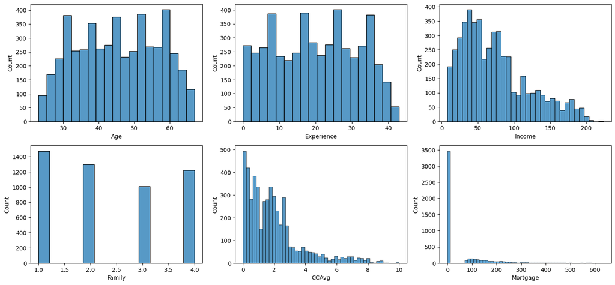

```python
# we will create histograms for the numerical variables to understand data distribution

# defining the figure size
plt.figure(figsize=(15, 10))

# defining the list of numerical features to plot
num_features = ['Age', 'Experience', 'Income', 'Family', 'CCAvg', 'Mortgage']

# plotting the histogram for each numerical feature
for i, feature in enumerate(num_features):
    plt.subplot(3, 3, i+1)    # assign subplots in the main plot
    sns.histplot(data=data, x=feature)    # plot the histogram

plt.tight_layout();   # to add spacing between plots
```

👉 Customer **age** and professional **experience** exhibit a fairly symmetrical distribution.  
👉 Annual **income** shows a right-skewed distribution.  
👉 **Family** size is almost symmetrical distribution.  
👉 Average monthly **credit card** spending and **mortgage** payments are highly right-skewed, with the vast majority of customers having no mortgage payments at all.

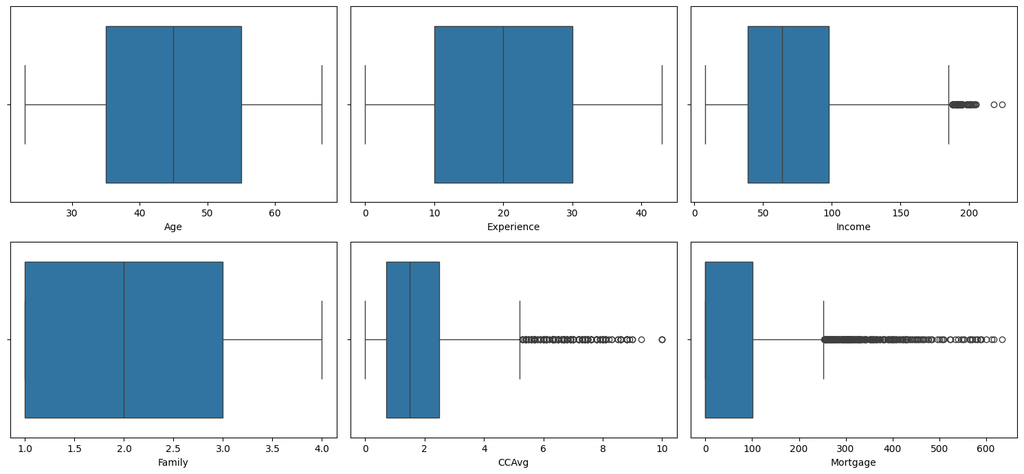

```python
# create boxplots to see outliers

# defining the figure size
plt.figure(figsize=(15, 10))

# plotting the boxplot for each numerical feature
for i, feature in enumerate(num_features):
    plt.subplot(3, 3, i+1)    # assign subplots in the main plot
    sns.boxplot(data=data, x=feature)    # plot the box-and-whisker diagram

plt.tight_layout();    # to add spacing between plots
```

👉 Customer **age** and professional **experience** show perfect distribution of the data.  
👉 There are outliers in **Income**, **Credit Card** payments, and **Mortgage** payments.  
👉 **Income**, **CCAvg**, and **Mortgage** are right-skewed, which is common with many economic-related data sets.  
👉 Customers with high value of mortgage can be potential customers.

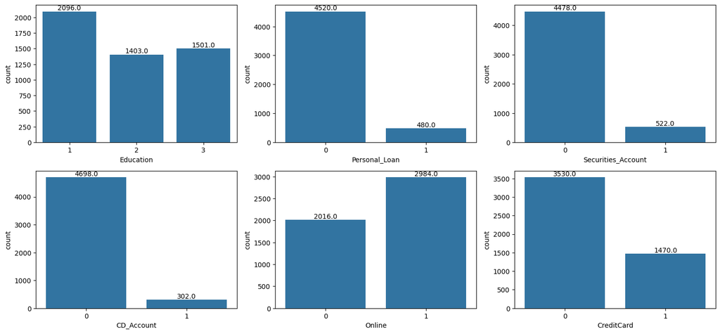

```python
# checking number of values in categorical attributes
categorical_columns = ['Education', 'Personal_Loan', 'Securities_Account', 'CD_Account', 'Online', 'CreditCard']

# defining the figure size
plt.figure(figsize=(15, 10))

# loop through each categorical variable and plot the count plot
for i, column in enumerate(categorical_columns, 1):
    plt.subplot(3, 3, i)  # assign subplots in the main plot
    ax = sns.countplot(data=data, x=column)

    # Add values on top of each bar
    for p in ax.patches:
        ax.annotate(f'{p.get_height()}', (p.get_x() + p.get_width() / 2, p.get_height()),
                    ha='center', va='bottom')
    plt.tight_layout()

plt.show()
```

👉 Only **1470** customers use credit cards issued by other banks. The majority of customers do not use credit cards from other banks.  
👉 The majority of customers use **online** banking. However, most do not have a **personal loan**, **securities account**, or **CD account** with us.  
👉 Counts for the other attributes can be seen in the graphs above.

#### Categorize the Education column values

```python
data["Education"].replace(1, "Undergraduate", inplace=True)
data["Education"].replace(2, "Graduate", inplace=True)
data["Education"].replace(3, "Advanced", inplace=True)
```

#### Bivariant Analysis

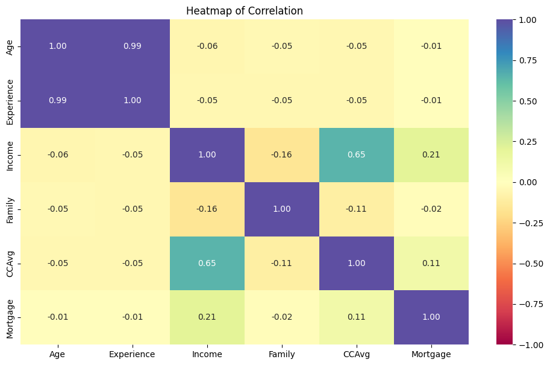

```python
# we will look into correlation and relationship between multiple variables

# defining the size of the plot
plt.figure(figsize=(12, 7))

# plotting the heatmap for correlation
sns.heatmap(
    data[num_features].corr(),annot=True, vmin=-1, vmax=1, fmt=".2f", cmap="Spectral"
)

plt.title('Heatmap of Correlation')
plt.show()
```

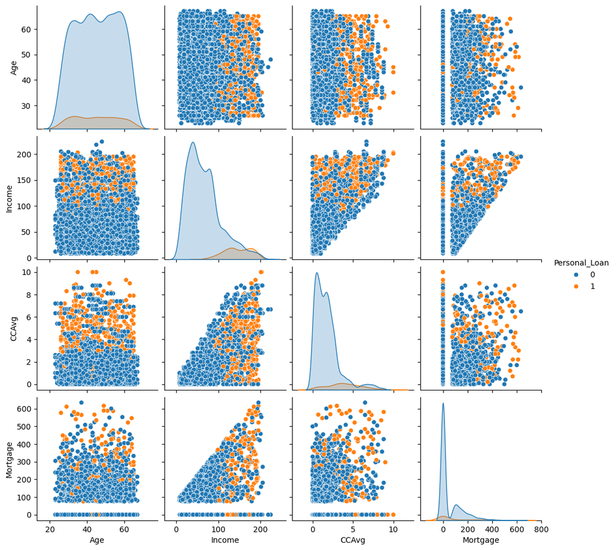

```python
# we will use scatter plot matrix to visualize relationships between variables

# exclude 'Experience', 'Family', 'Personal_Loan', and 'Education'
num_features_filtered = [col for col in num_features if col not in ['Experience', 'Family', 'Personal_Loan', 'Education']]

# create the pairplot
plt.figure(figsize=(12, 8))
sns.pairplot(data, vars=num_features_filtered, hue='Personal_Loan', diag_kind='kde');
```

👉 Customers with an **annual income higher than 100K** are more likely to take out a personal loan.  
👉 Customers with an **average credit card spending** of **3K per month and above** are more likely to take out a personal loan.  
👉 Customers with a **mortgage value** of **300K and above** are more likely to take out a personal loan.

#### Correlation Pairs

```python
# we will define a function to plot category counts and create a stacked bar chart based on the predictor and target variables
def stacked_barplot(data, predictor, target):
    """
    data: dataframe
    predictor: independent variable
    target: target variable
    """
    count = data[predictor].nunique()
    sorter = data[target].value_counts().index[-1]
    tab1 = pd.crosstab(data[predictor], data[target], margins=True).sort_values(
        by=sorter, ascending=False
    )
    print(tab1)
    print("-" * 120)
    tab = pd.crosstab(data[predictor], data[target], normalize="index").sort_values(
        by=sorter, ascending=False
    )
    tab.plot(kind="bar", stacked=True, figsize=(count + 5, 5))
    plt.legend(
        loc="lower left", frameon=False,
    )
    plt.legend(loc="upper left", bbox_to_anchor=(1, 1))
    plt.show()
```

```
Personal_Loan     0    1   All
Education
All            4520  480  5000
Advanced       1296  205  1501
Graduate       1221  182  1403
Undergraduate  2003   93  2096
------------------------------------------------------------------------------------------------------------------------
```

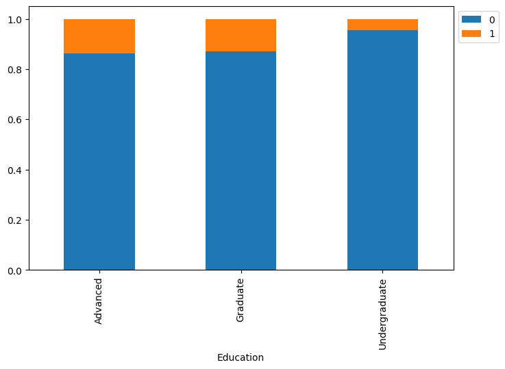

```python
# Personal_Loan vs Education
stacked_barplot(data, "Education", "Personal_Loan")
```

👉 Loan approval rates show a modest increase with higher education levels.

```
Personal_Loan     0    1   All
Family
All            4520  480  5000
4              1088  134  1222
3               877  133  1010
1              1365  107  1472
2              1190  106  1296
------------------------------------------------------------------------------------------------------------------------
```

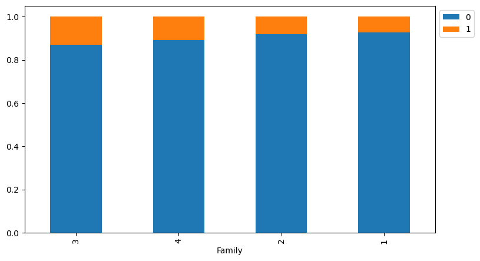

```python
# Personal_Loan vs Family size
stacked_barplot(data, "Family", "Personal_Loan")
```

```
Personal_Loan     0    1   All
CD_Account
All            4520  480  5000
0              4358  340  4698
1               162  140   302
------------------------------------------------------------------------------------------------------------------------
```

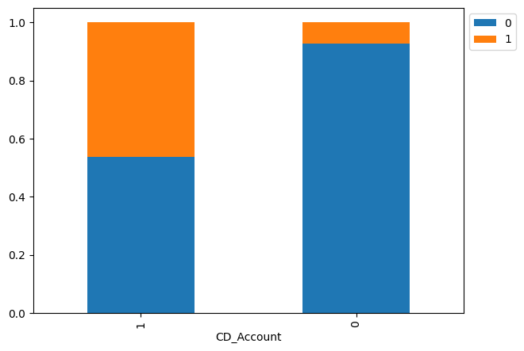

```python
# Personal_Loan vs CD_Account
stacked_barplot(data, "CD_Account", "Personal_Loan")
```

👉 Individuals with a CD account have significantly higher personal loan approval rates.

```python
### function to plot distributions wrt target

def distribution_plot_wrt_target(data, predictor, target):

    fig, axs = plt.subplots(2, 2, figsize=(12, 10))

    target_uniq = data[target].unique()

    axs[0, 0].set_title("Distribution of target for target=" + str(target_uniq[0]))
    sns.histplot(
        data=data[data[target] == target_uniq[0]],
        x=predictor,
        kde=True,
        ax=axs[0, 0],
        color="teal",
        stat="density",
    )

    axs[0, 1].set_title("Distribution of target for target=" + str(target_uniq[1]))
    sns.histplot(
        data=data[data[target] == target_uniq[1]],
        x=predictor,
        kde=True,
        ax=axs[0, 1],
        color="orange",
        stat="density",
    )

    axs[1, 0].set_title("Boxplot w.r.t target")
    sns.boxplot(data=data, x=target, y=predictor, ax=axs[1, 0], palette="gist_rainbow")

    axs[1, 1].set_title("Boxplot (without outliers) w.r.t target")
    sns.boxplot(
        data=data,
        x=target,
        y=predictor,
        ax=axs[1, 1],
        showfliers=False,
        palette="gist_rainbow",
    )

    plt.tight_layout()
    plt.show()
```